# Games in Normal Form

with Connor T. Wiegand

## Intro

### What do games look like?

- Normal form
  - via a *payoff matrix*
- Extensive form
  - via *game tree*
- Freeform text

### Roadmap

- Normal Form
  - Structure
  - Reducing
  - Equilibrium
  - Solving
- Extensive Form
  - Structure
  - Refined Equilibrium
  - Solving
  - Comparison with normal form
- Back to Normal Form
  - Full set of equilibrium
  - Solving
- Specific Games

## Normal Form Representation

### Simultaneous-move games

- Games in normal form use a table-like box called a payoff matrix
- This representation is typically used to represent simultaneous-move games
  - Or stages of a game which can be modelled as simultaneous-move play

#### Structure of Simultaneous-move games

- Players move at the same time
- They play once and never again
- There is no prior communication between the players.

### A Normal Form Game

- We will start with so-called “2x2” games (really 2x2x2)
  - 2 players
  - each with 2 strategies

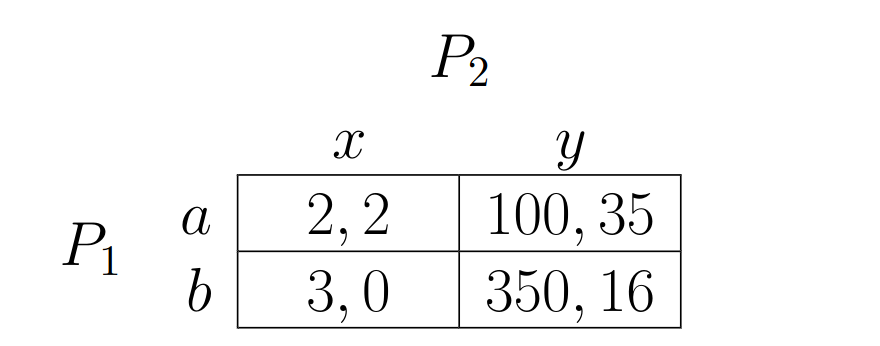

### Players

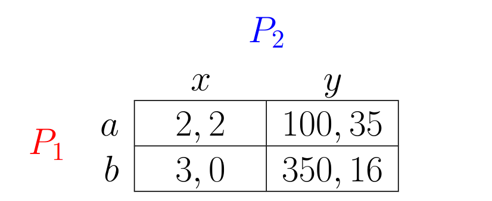

- Players:
  - Row player
    - Player 1
  - Column player
    - Player 2

### Strategies

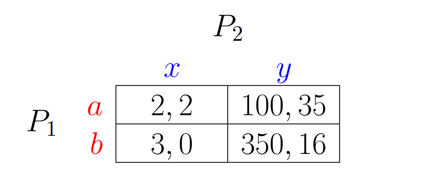

### Strategies (Math)

- Strategies
  - Moves available to the player
  - In general, let $S_{i}$ denote player $i$’s [strategy space]<sup>1</sup>
    - Ex: $S_{1}=\{a,b\}$, $S_2=\{x,y\}$
[^1]: or “set of strategies”

### Strategy Profiles

**Def:**

- A strategy profile $s$ specifies a strategy for each player in the game
- The set of strategy profiles, $S$, is equal to
  $$S=S_{1}\times\dots\times S_{n}$$
- Typically represented by an $n-$tuple: $s=(s_1,\dots,s_n)$ denotes a strategy profile where $s_1\in S_1$, $\dots$, $s_n\in S_n$
- Consider the strategy profile $(a,x)$
  - I may sometimes write $(ax)$, $ax$, or $a,x$ if I feel it is clear to do so
    - Please clarify if you are unsure
    - Please try to be clear + consistent in your own notation, for your grader’s sake

### Payoffs

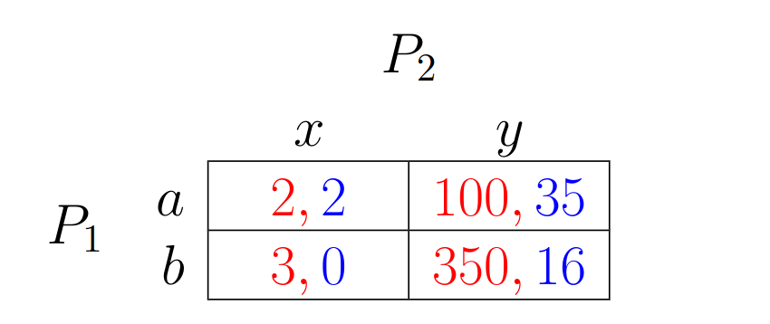

- Row player’s payoff always listed first
  - In general, payoffs are in order of player number

### Payoffs (Math)

- Properly speaking,
  $$\pi_i:S=S_{i}\times S_{-i}\to \mathbb{R}$$
- $S_{-i}$ denotes the set of strategies of all other players except for player $i$
  - $s_{-i}\in S_{-i}$ is one of such strategies
- We will keep order of inputs for $\pi_{i}$ independent of $i$:
  - $\pi_1(s_1,s_2)$ and $\pi_2(s_1,s_2)$
    - not: $\pi_2(s_2, s_1)$

## Towards an Equilibrium

### What is an equilibrium?

- What is our goal in modeling games?
- What do companies want you to be able to do with economic data?
- Goal: come up with a good **prediction** for the outcome of a game

### What is a good prediction?

- Recall our assumptions:
  - Common knowledge of the rules of the game
  - Common knowledge of rationality
  - Foreshadowing: given these two assumptions, should players experience regret at the end of a simultaneous-move game
- Key idea:
  - Let’s start by thinking about *bad* predictions, rather than good ones

## Dominated Strategies

### Definition

- A strategy $s_i, s_i'\in S_i$, we say $s_i$ **strictly dominates** $s_i'$ for player $i$ provided that
  $$u_i(s_i, s_{-i})>u_{i}(s_i', s_{-i})$$

  for all $s_{-i}\in S_{-i}$
- e.g., provided that $s_i$ does better than $s_i'$ for player $i$, [regardless of what my opponents do]
- **Note:** players may share strategies – or at least the abbreviation of a strategy – therefore, it is important to include which player we are talking about
  - …“for player $i$”
- I like using the preference symbol, $\succsim_{D}$, to denote domination:
  - “$s_{i}\succsim_{D} s_{i}'$ for player $i$” reads “$s_i$ dominates $s_i'$ for player $i$”

### Alt. Def.

- The previous definition can also be reversed to construct the notion of **strictly dominated by**
- You can use $\succsim_{D}$ for free to mean “dominates”. However, you must clearly note if you are using any shorthand for “is dominated by”

### Dominant Strategies

- Def: $s_{i}\in S_{i}$ is said to be **strictly dominant** if it strictly dominates all other $s_i'\in S_{i}$
- Dominant = better than everything else I can do, regardless of what my opponent does

### Weak Domination

- We can formulate any of the above definitions using the notion of weak dominance
- This replaces $u_i(s_i, s_{-i})>u_{i}(s_i', s_{-i})$ with $u_i(s_i, s_{-i})\ge u_{i}(s_i', s_{-i})$
- There is a reason we don’t want to do this, though
  - Forthcoming homework problem
- Note: Strict domination $\implies$ weak domination

### Examples: *PD*

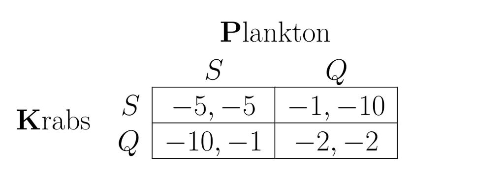

### Examples: *Chicken*

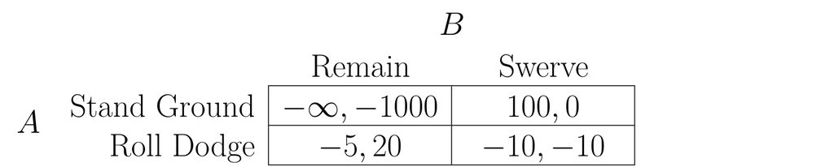

## IDSDS

### Recall:

- Recall common knowledge assumptions
- If both players know the rules of the game, they can both work out dominated strategies
- Rational players won’t play dominated strategies
- Idea: once both players figure this out, they should just *remove the dominated strategy from the game*